# Olympics Report

2022-06-21

## 0.1 data & packages setup

```r
#loading required packages
library(tidyverse)
library(skimr)
library(DT)
library(janitor)
library(GGally)
library(here)
library(kableExtra)
library(tidytuesdayR)

#import data
tuesdata <- tidytuesdayR::tt_load("2021-07-27")
# Individual dataframes
olympics <- tuesdata$olympics

# A second dataframe is available
# It is not required, but may prove useful in certain cases
regions <- tuesdata$regions
olympics$medal <- factor(olympics$medal,levels = c("Gold","Silver","Bronze"))
olympics$season <- factor(olympics$season,levels = c("Summer","Winter"))
olympics$sex <-  factor(olympics$sex,levels = c("M","F"))
```

# 1 DATA

The dataset contains the following variables:

| Variable | Type | Description |
| --- | --- | --- |
| id | double | Athlete unique ID |
| name | character | Athlete Name |
| sex | character | Athlete Sex |
| age | double | Athlete Age |
| height | double | Athlete Height (cm) |
| weight | double | Athlete weight (kg) |
| team | character | Team name, typically a country name |
| noc | character | NOC 3-letter country code |
| games | character | 4-digit year + season |
| year | double | 4-digit year |
| season | character | Season |
| city | character | Host city |
| sport | character | Sport |
| event | character | Sport + Event Name |
| medal | character | Medal: Gold, Silver, Bronze, (plus NA values) |

abstract summary for the dataset

```r
  olympics %>%
  select(sex,age,height,weight,year,season,medal)%>%
  summary()
```

[output not shown]

# 2 EDA

## 2.1 firstly have an abstract look on the data

### 2.1.1 list of all sports Olympics did cover since 1896

```r
#list of all sports Olympics did cover since 1896
olympics %>%
  select(sport) %>%
  distinct()%>%
  datatable()
```

|  | sport |
| --- | --- |
| 1 | Basketball |
| 2 | Judo |
| 3 | Football |
| 4 | Tug-Of-War |
| 5 | Speed Skating |
| 6 | Cross Country Skiing |
| 7 | Athletics |
| 8 | Ice Hockey |
| 9 | Swimming |
| 10 | Badminton |

[output cut: 56 more lines]

### 2.1.2 average wight of all Olympics participants since 1896

```r
olympics %>%
  filter(!is.na(weight)) %>%
  summarise(mean = mean(weight)) %>%
  print.table()
```

```
    mean
70.70239
```

### 2.1.3 average height of all Olympics participants since 1896

```r
olympics %>%
  filter(!is.na(height)) %>%
  summarise(mean = mean(height))%>%
  print.table()
```

```
   mean
175.339
```

### 2.1.4 average age of all Olympics participants since 1896

```r
olympics %>%
  filter(!is.na(age)) %>%
  summarise(mean = mean(age))%>%
  print.table()
```

```
   mean
25.5569
```

### 2.1.5 Top 20 teams with respect to number of medals

The US has the highest number of medals this may be a result of the high population, the diversity, which enables them to have more options in each sport and have a high number of athletes as we can see in 2.1.6

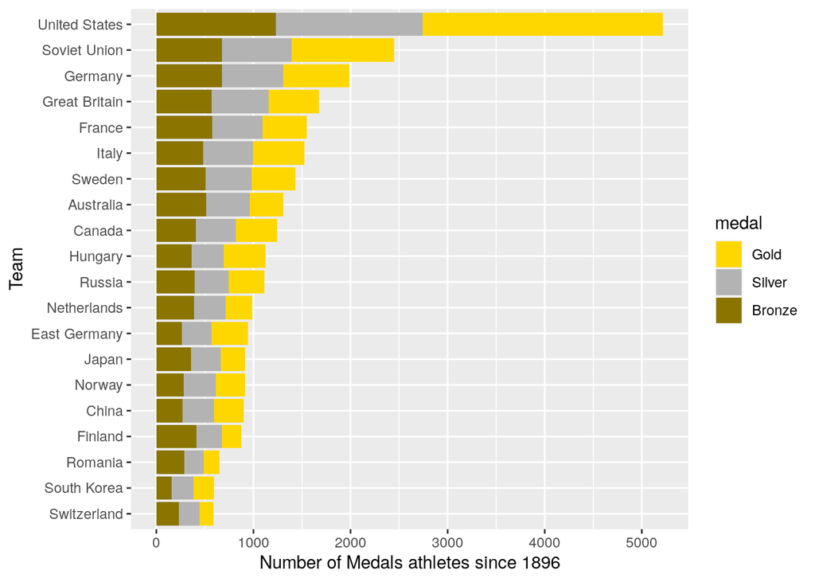

```r
# count number of medals for each team
medal_counts <- olympics %>% filter(!is.na(medal))%>%
  group_by(team, medal) %>%
  summarize(Count=length(medal))

# order team by total medal count
levs_art <- medal_counts %>%
  group_by(team) %>%
  summarize(Total=sum(Count)) %>%
  arrange(Total) %>%
  select(team) %>%
  tail(n=20)

medal_counts$team <- factor(medal_counts$team, levels=levs_art$team)
medal_counts <- medal_counts %>% filter(!is.na(team))


# plot
ggplot(medal_counts, aes(x=team, y=Count, fill=medal)) +
  geom_col() +
  coord_flip() +
  scale_fill_manual(values=c("gold1","gray70","gold4")) +
  theme(plot.title = element_text(hjust = 0.5))+
  labs(x="Team",y="Number of Medals athletes since 1896")
```

### 2.1.6 Number of athletes per countery

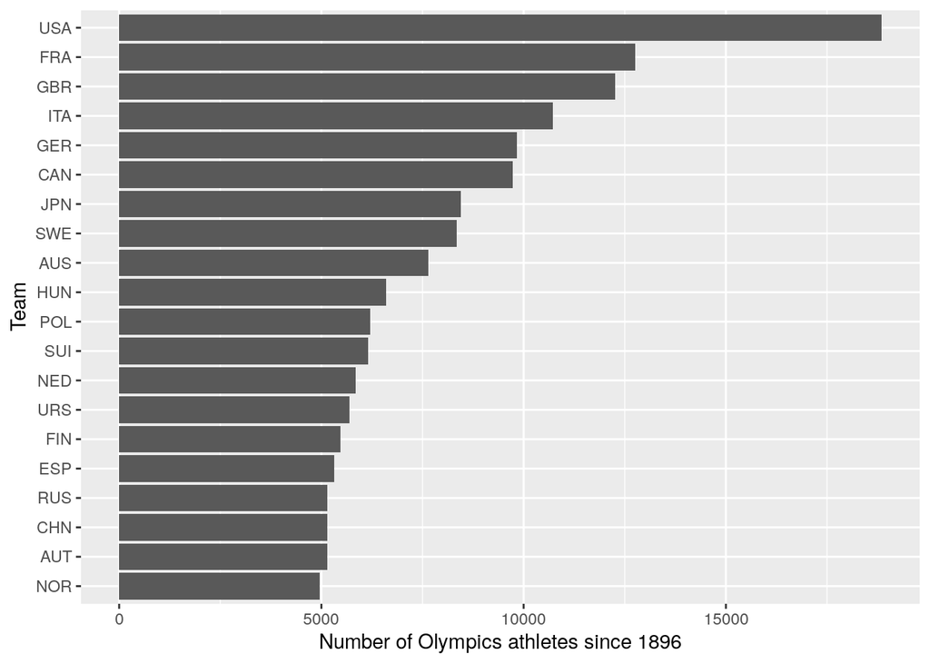

```r
olympics %>%
  group_by(noc) %>%
  count(name) %>%
  summarise(count = sum(n)) %>%
  arrange(count) %>%
  tail(n=20) %>%

#plot
ggplot(aes(x= reorder(noc,count), y=count)) +
 geom_col() +
 coord_flip() +
 labs(x="Team",y="Number of Olympics athletes since 1896")
```

### 2.1.7 who got the most medals

Michael Phelps, an American swimmer, who the most medals in the Olympic history.

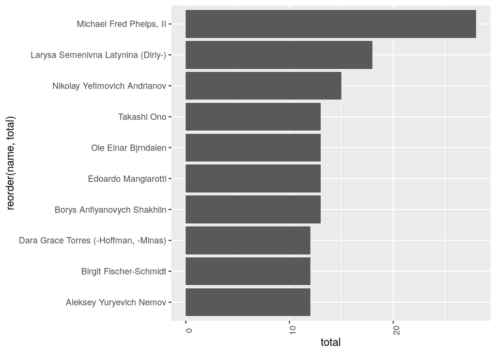

```r
olympics %>%
  filter(!is.na(medal)) %>%
  group_by(name) %>%
  summarise(name , total = length(medal)) %>%  distinct() %>%
  arrange( desc(total)  ) %>%  head(10)  -> medalyPerson


medalyPerson %>%
ggplot(aes(reorder(name,total) , total)) + geom_bar(stat =  "identity") +theme(axis.text.x = element_text(angle = 90)) + coord_flip()
```

### 2.1.8 Number of football medals by each team from 2000-2016

Shows the chart number of football medals by each team from 2000-2016 . The Brazil has the largest number medals, followed by Germany.

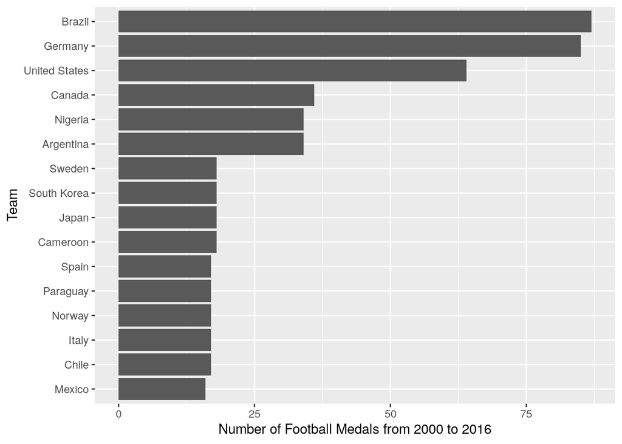

```r
football_teams_medals<- olympics %>%
  filter(sport == "Football", year >= 2000,!is.na(medal)) %>%
  group_by(team) %>%
  summarise(count=length(year)) %>%
  arrange(count)
#plot
football_teams_medals %>%
  ggplot(aes( x= reorder(team,count),y= count)) +
  geom_col() +
  coord_flip() +
  labs(x="Team",y="Number of Football Medals from 2000 to 2016")
```

## 2.2 now lets take a look if number of female athlete has increased since 1897 and if did why ?

Interest NOCs are leading the way for gender equality in the Olympics,so some NOCs even sent a majority of female athletes to the Games ,In 1996 and 2016. The chart shows asimprovement in female participation from 1956 to 2016 .

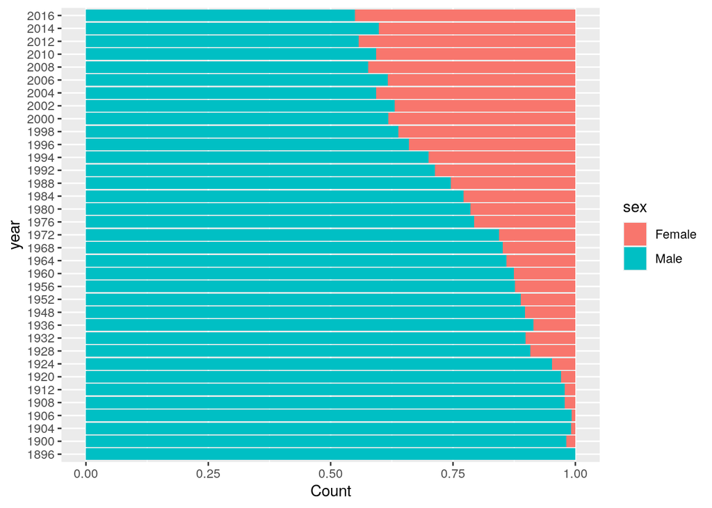

```r
#count the number of females and males for each year
counts_sex <- olympics %>%
  group_by(year, sex) %>%
  summarize(Count = length(unique(id))) %>%
  spread(sex, Count)

#clean the data
counts_sex$M[is.na(counts_sex$M)] <- 0
counts_sex$F[is.na(counts_sex$F)] <- 0
counts_sex$year <- as.factor(counts_sex$year)

#calculate the total on participants
counts_sex <- mutate(counts_sex,Total = sum(M,F,na.rm=T))

#calculate the percentage of females and males from the total
counts_sex$M <- counts_sex$M/counts_sex$Total
counts_sex$F <- counts_sex$F/counts_sex$Total

#creating the graph
names(counts_sex)[2:3] <- c("Male","Female")
counts_sex <- gather(counts_sex,key= sex , value = Count,2:3)

ggplot(counts_sex,aes(x=year,y=Count,fill=sex)) +
  geom_col() +
  coord_flip()
```

## 2.3 changes of athletes’ height,weight and BMI over time

height, weight has a similar trend as the reach the minimum point between 1950-1960 and they start to increase again. before that the plot shows that the athlete tend to have lower weights, the decrease in the weight is higher and faster than the height. since the events are changing constantly overall this plot implies that the new events require high height and weight.

### 2.3.1 Height

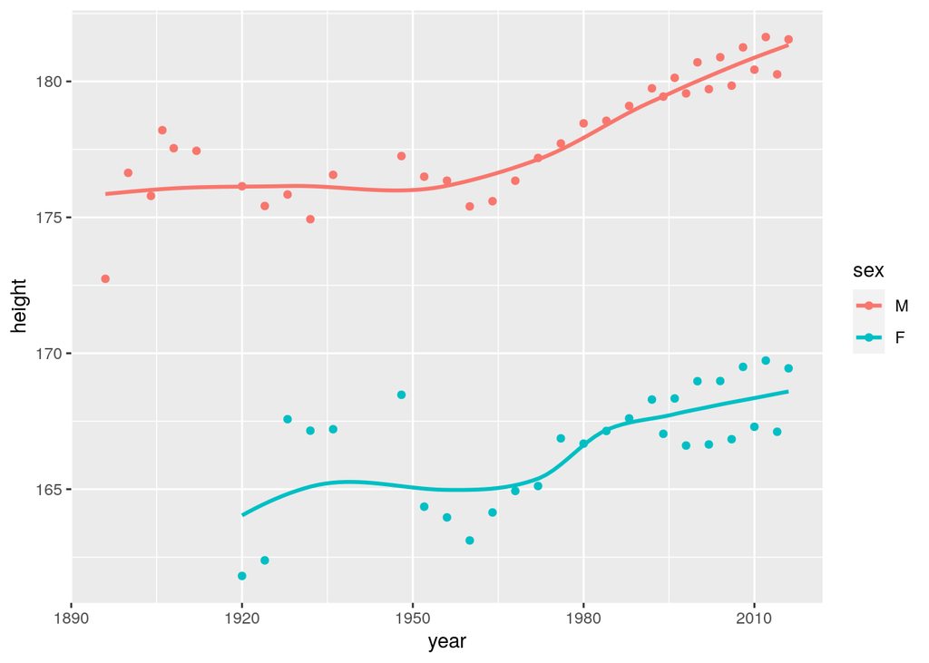

```r
olympics %>%
  filter(!is.na(height)) %>%
  group_by(year , sex) %>%
  summarise( height= mean(height))-> avgHight

ggplot(avgHight , aes(year , height , color = sex)) + geom_point()+ geom_smooth(se = FALSE)
```

### 2.3.2 Weight

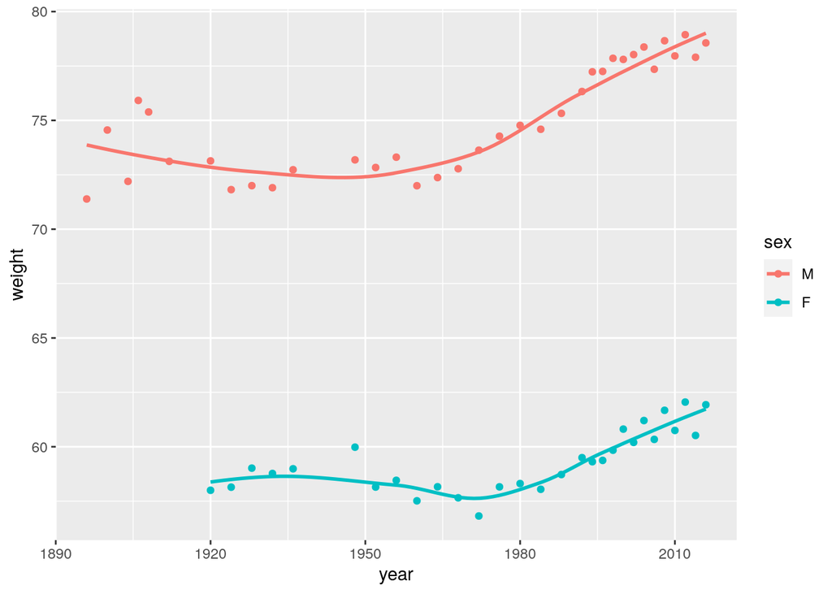

```r
olympics %>%
  filter(!is.na(weight)) %>%
  group_by(year , sex) %>%
  summarise( weight= mean(weight))-> avgWeight

ggplot(avgWeight , aes(year , weight , color= sex)) + geom_point()+ geom_smooth(se = FALSE)
```

### 2.3.3 BMI

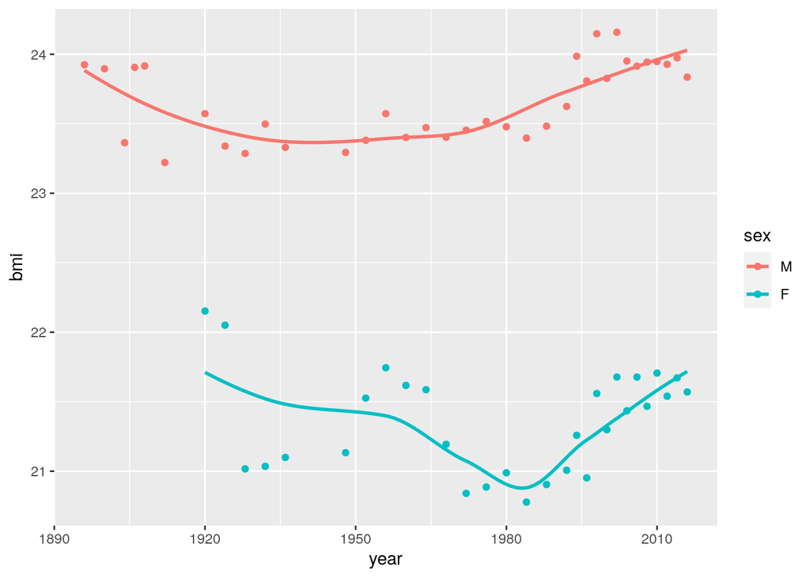

```r
avgBMI <- avgHight
avgBMI$weight <- avgWeight$weight

avgBMI <- avgBMI %>%
  mutate(bmi = (weight)/(height/100 * height/100))

ggplot(avgBMI ,aes(year , bmi , color = sex) )+ geom_point()+ geom_smooth(se = FALSE)
```

## 2.4 did WW2 had an effecton Olympics games and how ?

### 2.4.1 How did the Olympics suffer from the WWII

this shows that the number of games per year the circle is where the War happen we se that the Number of games were damaged in that era.

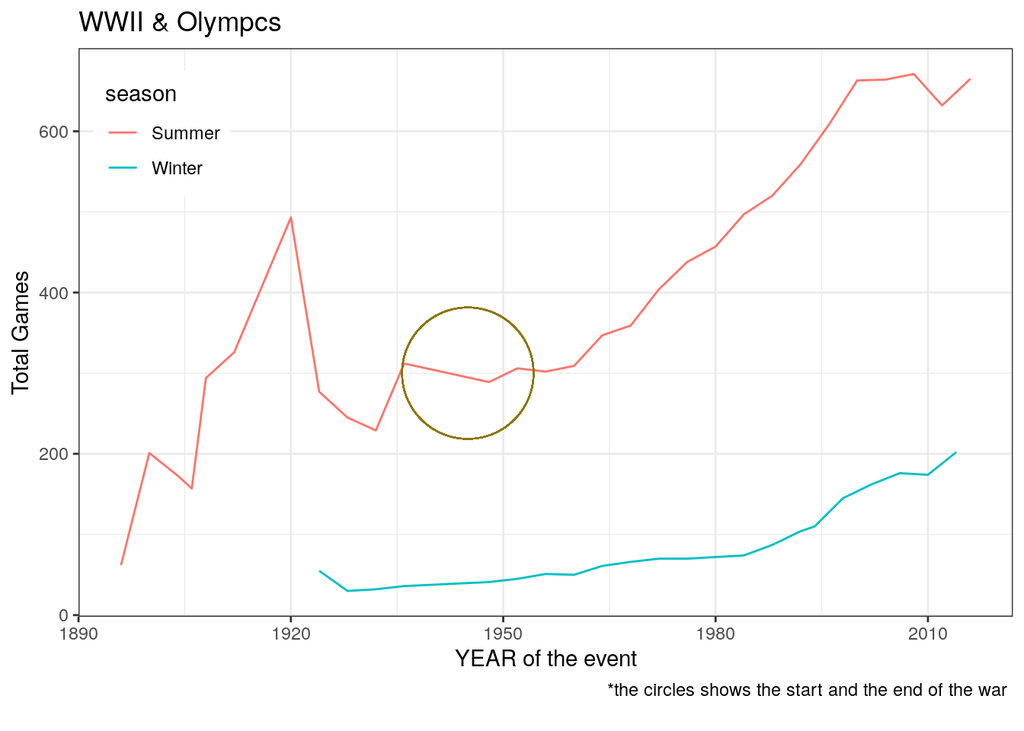

```r
medal2 <-
  olympics %>%
  group_by(year, medal = medal=="Gold" , season) %>% #the idea here is when we group by medal = gold this will show us the number of games (one medal per game)
  summarise(
    TotalMedal = length(medal) ## i dont know whay na.rm do yet but when i remove it the graph change a lot
  )
medal2 %>%
  filter(medal , medal == TRUE)    ->medal ##the idea here is will count the number of true(medal == gold) in each year summer or
ggplot(medal , aes(year , TotalMedal  , color = season)) + geom_line() +
  geom_point(aes(x=1945, y=300), size=30, shape=1, color="gold4") +
  labs(title ="WWII & Olympcs " ,y = "Total Games", x = "YEAR of the event" , caption = "*the circles shows the start and the end of the war \n   ") +
  # please change the title to good name
  theme_bw() + theme(legend.position = c(.09,.85) , )
```

### 2.4.2 Germany in wrold war 2

This shows the number of Participants in each olympics we can see that in the war time there were none.

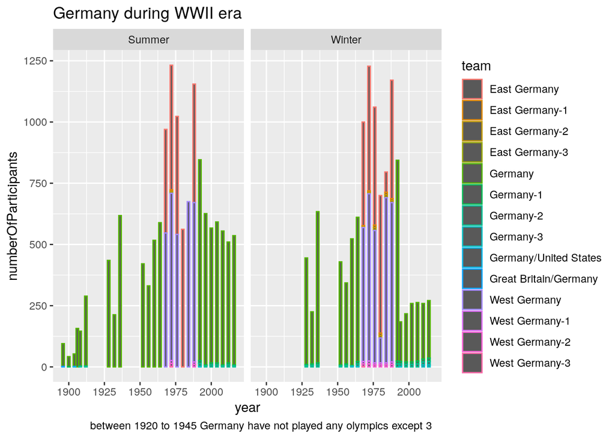

```r
olympics %>%
  group_by(team , year ) %>%
  filter(grepl("Germany", team)) %>%

  # filter(team == "Germany" | team == "*Germany" ) %>%
  summarise( team , year , numberOfParticipants= length(name) ,season) %>%
  distinct() -> GermanyDataset

GermanyDataset  %>%
  ggplot(aes(year ,numberOfParticipants , color = team )) + geom_bar(stat = "identity")+ ##  I dont like this plot but

  facet_grid(. ~ season) +
  labs(title = "Germany during WWII era" , caption = " between 1920 to 1945 Germany have not played any olympics except 3   ")
```

## 2.5 does the age of the athlete effect on his/her performance?

as we know older people elders are worse in sports than younger, but does this fact also apply on Olympic athlete ?

### 2.5.1 The changes of avg age of athelte over time

in this plot we can see the average age of Olympic athlete since 1897 to 2016,an we can see that mean of age increses between 1912 and 1948, this doesn’t mean their generation was stronger or they were eating healthy this is acullty in those years there was a few events that allows elders to participate and win e.g. art competition.

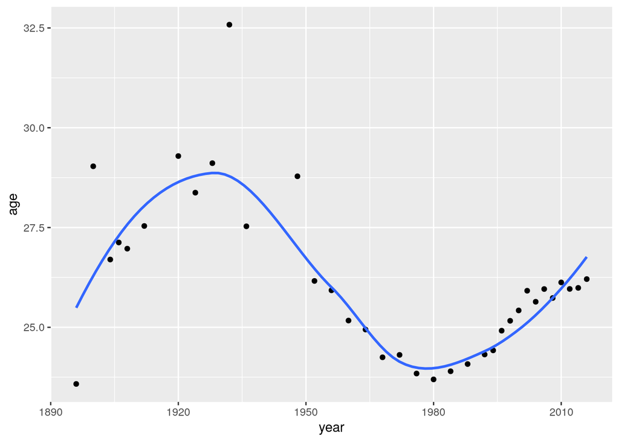

```r
olympics %>%
  select(year , team,age) %>%
  filter(!is.na(age)) %>%
  group_by(year) %>%
  summarise(age = mean(age)) -> avrgAgeInEachYear

ggplot(avrgAgeInEachYear , aes(year , age)) + geom_point()+ geom_smooth(se = FALSE)
```

### 2.5.2 How old are most of the winners and losers?

this plot tells us the density of elder losers is actually higher the the density of elder winnerss,so this means yes younger actually have more wining possibility than elders.

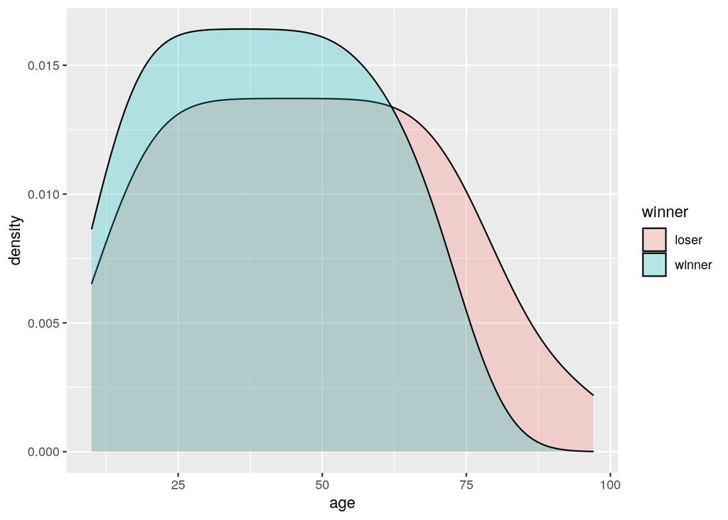

```r
winnersVslosers <- olympics %>%
  mutate(winner = if_else(is.na(medal),"loser","winner"))

winnersVslosers$winner <- factor(winnersVslosers$winner,levels = c("loser","winner"))

winnersVslosers %>%
  filter(!is.na(age)) %>%
  group_by(winner,age) %>%
  summarise(count=n()) -> winnersVslosers

#plot
winnersVslosers %>%
  ggplot(aes(x=age ,fill= winner)) +
  geom_density(alpha=0.25)
```

### 2.5.3 Mean of age in year With respect of kind of model

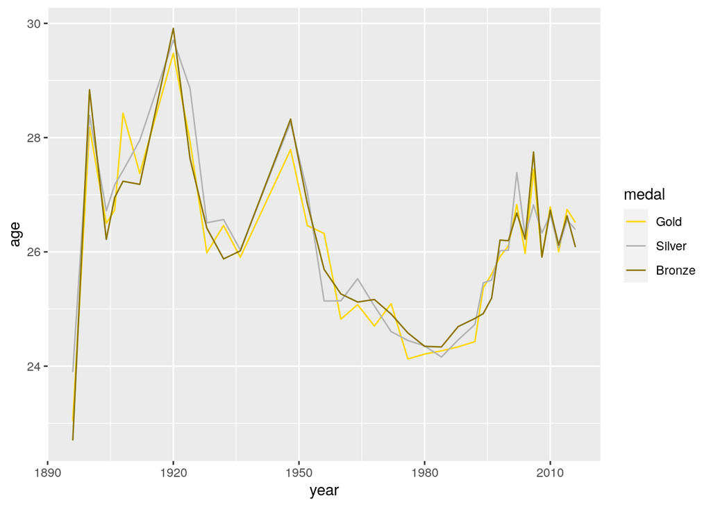

```r
medal <-
  olympics %>%
  filter(!is.na(age),!is.na(medal)) %>%
  group_by(year, medal) %>%
  summarise(age = mean(age))

#plot
ggplot(medal , aes(x=year , y=age, color = medal)) + geom_line() +
scale_color_manual(values=c("gold1","gray70","gold4"))
```

### 2.5.4 kids who got Olympics models(less than 13)

this table shows kids who have won an Olympic medal and what events they won in, it tells us that kids have more possiplty to win a medal if they were within Gymnastics events.

```r
#is there any kids(less than 13) got an Olympic medals?
olympics %>%
  filter(age<13, !is.na(medal)) %>%
  datatable()
```

|  | id | name | sex | age | height | weight | team | noc | games | year | season | city | sport | event | medal |
| --- | --- | --- | --- | --- | --- | --- | --- | --- | --- | --- | --- | --- | --- | --- | --- |
| 1 | 40129 | Luigina Giavotti | F | 11 |  |  | Italy | ITA | 1928 Summer | 1928 | Summer | Amsterdam | Gymnastics | Gymnastics Women's Team All-Around | Silver |
| 2 | 71691 | Dimitrios Loundras | M | 10 |  |  | Ethnikos Gymnastikos Syllogos | GRE | 1896 Summer | 1896 | Summer | Athina | Gymnastics | Gymnastics Men's Parallel Bars, Teams | Bronze |
| 3 | 74712 | Carla Marangoni | F | 12 |  |  | Italy | ITA | 1928 Summer | 1928 | Summer | Amsterdam | Gymnastics | Gymnastics Women's Team All-Around | Silver |
| 4 | 96664 | Dorothy Poynton-Hill (-Teuber) | F | 12 |  |  | United States | USA | 1928 Summer | 1928 | Summer | Amsterdam | Diving | Diving Women's Springboard | Silver |
| 5 | 113580 | Inge Srensen (-Tabur) | F | 12 |  |  | Denmark | DEN | 1936 Summer | 1936 | Summer | Berlin | Swimming | Swimming Women's 200 metres Breaststroke | Bronze |
| 6 | 125092 | tienne Nol Henri Vandernotte | M | 12 |  | 37 | France | FRA | 1936 Summer | 1936 | Summer | Berlin | Rowing | Rowing Men's Coxed Pairs | Bronze |
| 7 | 125092 | tienne Nol Henri Vandernotte | M | 12 |  | 37 | France | FRA | 1936 Summer | 1936 | Summer | Berlin | Rowing | Rowing Men's Coxed Fours | Bronze |
| 8 | 125944 | Ines Vercesi | F | 12 |  |  | Italy | ITA | 1928 Summer | 1928 | Summer | Amsterdam | Gymnastics | Gymnastics Women's Team All-Around | Silver |

### 2.5.5 elders who got Olympics models(above 65)

this table shows elders who have won an Olympic medal and what events they won in, it tells us that elders have more possibility to win a medal if they were within Art events but unfortunately they stopped a long time ago.

```r
#is there any elders(above 65) got an Olympic medals?

olympics %>%
        filter(age>65, !is.na(medal)) %>%
  datatable()
```

|  | id | name | sex | age | height | weight | team | noc | games | year | season | city | sport | event | medal |
| --- | --- | --- | --- | --- | --- | --- | --- | --- | --- | --- | --- | --- | --- | --- | --- |
| 1 | 22984 | John (Herbert Crawford-) Copley (Williamson-) | M | 73 |  |  | Great Britain | GBR | 1948 Summer | 1948 | Summer | London | Art Competitions | Art Competitions Mixed Painting, Graphic Arts | Silver |
| 2 | 30731 | Jozu Dupon | M | 72 |  |  | Belgium | BEL | 1936 Summer | 1936 | Summer | Berlin | Art Competitions | Art Competitions Mixed Sculpturing, Medals | Bronze |
| 3 | 30932 | Samuel Harding Duvall | M | 68 |  |  | Cincinnati Archers | USA | 1904 Summer | 1904 | Summer | St. Louis | Archery | Archery Men's Team Round | Silver |
| 4 | 45286 | Letitia Marion Hamilton | F | 69 |  |  | Ireland | IRL | 1948 Summer | 1948 | Summer | London | Art Competitions | Art Competitions Mixed Painting, Paintings | Bronze |
| 5 | 73120 | Frederick William MacMonnies | M | 68 |  |  | United States | USA | 1932 Summer | 1932 | Summer | Los Angeles | Art Competitions | Art Competitions Mixed Sculpturing, Medals And Reliefs | Silver |
| 6 | 75648 | Charles William Martin | M | 71 |  |  | Crabe II-1 | FRA | 1900 Summer | 1900 | Summer | Paris | Sailing | Sailing Mixed 0.5-1 Ton | Silver |
| 7 | 75648 | Charles William Martin | M | 71 |  |  | Crabe II-4 | FRA | 1900 Summer | 1900 | Summer | Paris | Sailing | Sailing Mixed 0.5-1 Ton | Bronze |
| 8 | 87135 | Louis Noverraz | M | 66 | 179 | 78 | Switzerland | SUI | 1968 Summer | 1968 | Summer | Mexico City | Sailing | Sailing Mixed 5.5 metres | Silver |
| 9 | 93875 | Josef Petersen | M | 66 |  |  | Denmark | DEN | 1948 Summer | 1948 | Summer | London | Art Competitions | Art Competitions Mixed Literature, Epic Works | Silver |
| 10 | 117046 | Oscar Gomer Swahn | M | 72 |  |  | Sweden | SWE | 1920 Summer | 1920 | Summer | Antwerpen | Shooting | Shooting Men's Running Target, Double Shot, Team | Silver |

[output cut: 1 more lines]

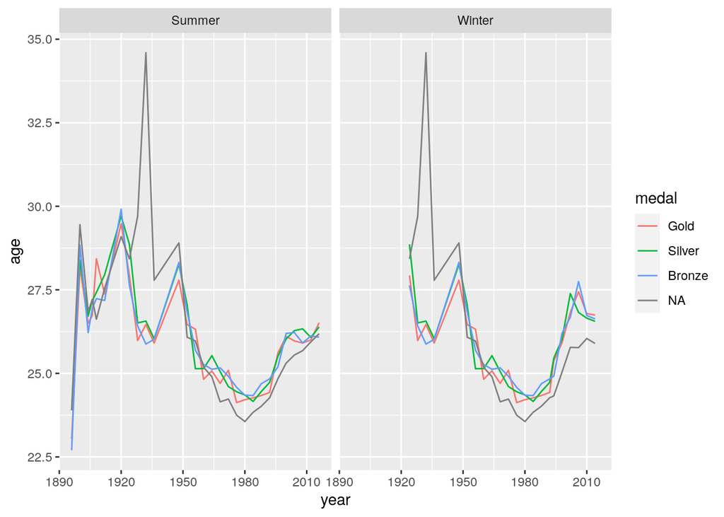

```r
   medal <- olympics %>%
  group_by(year, medal) %>%
  summarise( age = mean(age, na.rm = TRUE ) , season =season)
###--- plot for medal per year

ggplot(medal , aes(x=year , y= age  , color = medal )) + geom_line() +   facet_grid(. ~ season) #summer and winter game
```

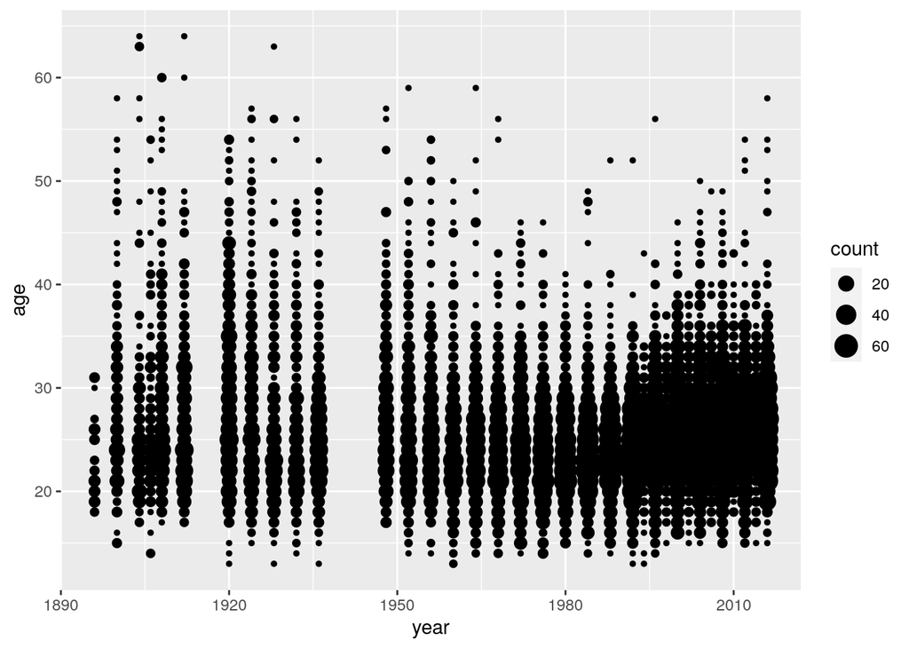

```r
AgeAndHowManyGold <-
  olympics %>%
  group_by(year,age, medal) %>%
  filter(medal == "Gold",!is.na(age)) %>%
  summarise(count = n() )

    ggplot(AgeAndHowManyGold , aes(x=year ,age   ,size = count)) + geom_point()  ## this will show only gold medal
```

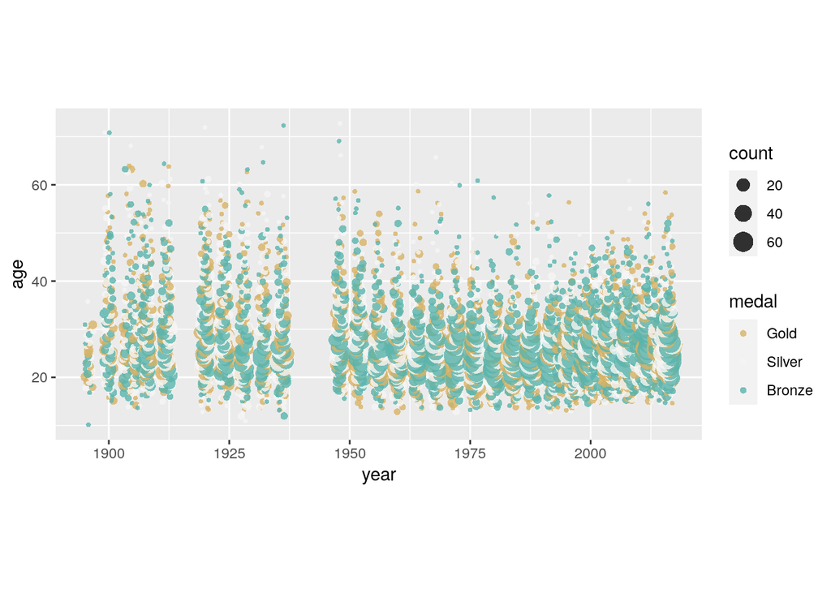

```r
AgeAndHowManyMedal <-
     olympics %>%
     group_by(year,age, medal) %>%
     filter(!is.na(medal),!is.na(age)) %>%
     summarise(count = n() )

ggplot(AgeAndHowManyMedal , aes(x=year ,age , color = medal  ,size = count)) +  geom_jitter(alpha = 0.8, shape = 16 , width =1) +
  coord_fixed() + scale_color_brewer(palette = "BrBG") ## this will show ALL medal
```

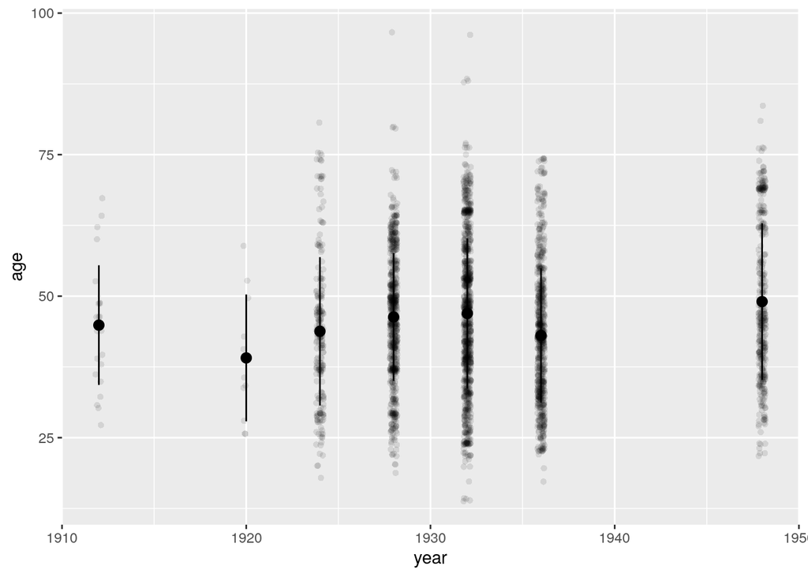

```r
olympics %>%
  filter(grepl('Art', sport)) ->artAge
artAge %>%
  group_by(year) %>%
  summarise(year, age) %>%
 filter(!is.na(age)) ->artAge

ggplot(artAge, aes(year, age)) +
  geom_jitter(width = 0.2, alpha = 0.1, shape = 16) +
  stat_summary(fun.data = mean_sdl,
               fun.args = list(mult = 1))
```

# 3 Conclusion

- he US has the highest number of medals and athletes.
- Brazil has the highest number of medals in football.
- Female participation in the Olympic Games is on the rise. -The size of Olympians have become more extreme over time in most sports this means taller and heavier, but in a few sports such as gymnastics, athletes have become smaller.
- The proportion of winners athletes with ages below 60 is higher than that above 60.
- The Olympic Games plays a vital role in fostering unity among nations.